# Introdução (Aula 0)

16 de setembro de 2017

## Curso-R

- Athos Damiani
- Daniel Falbel
- Fernando Correa
- Julio Trecenti
- William Amorim

## Curso-R

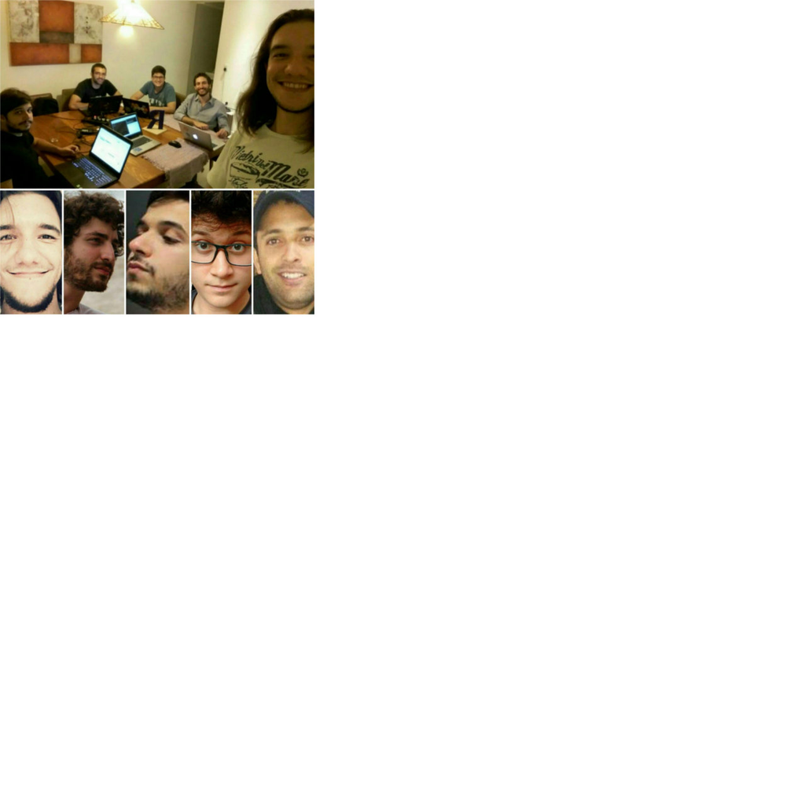

## Ciência de dados

[figure not shown]

## Papel do R

R é a grande cola.

**Exemplo:** Tensorflow, feito em Python, chamado no R pelo pacote keras.

```r
library(keras)

modelo <- keras_model(input = 1)
```

## Nosso curso

16/09 - Introdução + R base - Fernando

16/09 - Vetores + R base - Athos

23/09 - Dplyr - Julio

23/09 - ggplot2 - Daniel

## Nosso curso

Nosso curso se baseia no livro *R for data science*:

http://r4ds.had.co.nz

O melhor lugar para aprender sobre o `tidyverse` depois do Curso-R.

[figure not shown]

## Nosso curso

O material do curso está disponível nessa página (em desenvolvimento):

http://material.curso-r.com/

Também temos um blog:

http://curso-r.com/blog/

## Dinâmica

- Almoço às 12h.
- Aulas expositivas em blocos de 3h.
- Exercícios ao decorrer e no final das aulas.
- Leituras e exercícios complementares e opcionais fora da sala de aula.

## Dinâmica

**Aula 1**

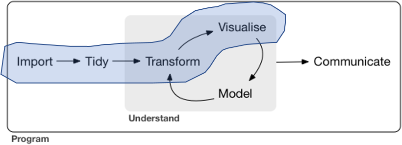

## Dinâmica

**Aula 2**

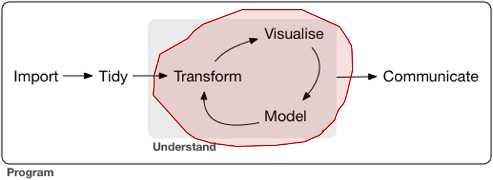

## Dinâmica

**Pacotes**

[figure not shown]

## Não vamos falar de

- Estatística multivariada (unsupervised learning, clustering, componentes principais)
- Gráficos dinâmicos e dashboards (Shiny, htmlwidgets)
- Programação eficiente com R (paralelização, *profiling*, `Rcpp`)
- Não vamos nos aprofundar em "big data" (Spark, Hadoop, MongoDB, TensorFlow)

## Tidyverse

O universo arrumadinho.

Revolução do R. Quem mexia em R antes de 2012 nota uma diferença gigante.

[figure not shown]

## Princípios do tidyverse

- *Eficiência algorítmica vs eficiência de trabalho*. O tempo gasto pensando em como realizar uma operação é mais importante do que o tempo que o computador gasta para realizar um cálculo.
- *Tidy data*. Princípio para arrumação de base de dados que resolve 90% dos problemas reais. Base tidy:
  - Cada observação é uma linha do bd.
  - Cada variável é uma coluna do bd.
  - Cada dado está numa célula do bd.

## Estrutura do tidyverse

- *Aparato mnemônico*. Pacotes baseados em teoria e API consistentes.
- *Minimalidade e funções puras*. Funções sem efeitos colaterais. Inputs e Outputs consistentes. Encaixa perfeitamente com o uso do pipe (%>%).
- *procedimentos* para ciência de dados.

## GitHub

- Maior plataforma online para compartilhar códigos.
- Utiliza o **Git**, a melhor ferramenta de versionamento de software.

*Vantagens*:

1. Boa prática de organizar projetos pois mantém os códigos organizados e atualizados na web.
2. Projetos colaborativos: aumenta a produtividade e permite que pessoas de todo lugar ajudem nos projetos.
3. O `tidyverse` só é o que é hoje por conta do *social coding*.

## GitHub

Um tutorial para começar a [usar Github no RStudio rapidamente](http://curso-r.com/blog/2017/07/17/2017-07-17-rstudio-e-github/)

Para detalhes, faça o [data science toolbox](https://www.coursera.org/learn/data-scientists-tools)

## Exercício da aula zero

Anotar em uma folha de papel ou virtual:

- http://material.curso-r.com/
- Tidyverse
- pipe (%>%)
- Github